# Optimization

Johanna Daas

10 12 2020

This document follows closely the [Mendez 2009 paper](https://doi.org/10.1007/978-1-59745-525-1_2)[^1] on **COPASI** use cases.

If we want to optimize something, we either want to *minimize* or *maximize* a specific task value.

# Setup

First, we have to load **CoRC** and **tidyverse**. Make sure you have these packages downloaded.

```r
library(CoRC)
library(tidyverse)
```

# Loading the model

We will work with model [Nr. 23 in BioModels](https://www.ebi.ac.uk/biomodels/BIOMD0000000023)[^2], which is a simulation of analyzing sucrose accumulation in sugar cane (Rohwer 2001).

```r
loadSBML("https://www.ebi.ac.uk/biomodels/model/download/BIOMD0000000023?filename=BIOMD0000000023_url.xml")
```

```
## # A COPASI model reference:
## Model name: "Rohwer2001_Sucrose"
## Number of compartments: 1
## Number of species: 13
## Number of reactions: 11
```

We will first take a look at the reactions:

```r
getReactions()
```

```
## # A tibble: 11 x 6
##    key   name  reaction              rate_law                   flux number_flux
##    <chr> <chr> <chr>                 <chr>                     <dbl>       <dbl>
##  1 (v1)  v1    Fruex = Fru           FunctionDB.Functions[Fun~     0           0
##  2 (v2)  v2    Glcex = Glc           FunctionDB.Functions[Fun~     0           0
##  3 (v3)  v3    ATP + Glc = HexP + A~ FunctionDB.Functions[Fun~     0           0
##  4 (v4)  v4    Fru + ATP = HexP + A~ FunctionDB.Functions[Fun~     0           0
##  5 (v5)  v5    Fru + ATP = HexP + A~ FunctionDB.Functions[Fun~     0           0
##  6 (v6)  v6    2 * HexP = UDP + Suc~ FunctionDB.Functions[Fun~     0           0
##  7 (v7)  v7    Suc6P = Suc + phos    FunctionDB.Functions[Fun~     0           0
##  8 (v8)  v8    HexP + Fru = Suc + U~ FunctionDB.Functions[Fun~     0           0
##  9 (v9)  v9    Suc = Fru + Glc       FunctionDB.Functions[Fun~     0           0
## 10 (v10) v10   HexP = glycolysis     FunctionDB.Functions[Fun~     0           0
## 11 (v11) v11   Suc = Sucvac          FunctionDB.Functions[Fun~     0           0
```

Of interest to us are reactions *v11* (accumulation of sucrose in vacuoles) and *v9* (hydrolysis of sucrose), which decreases our overall productivity.

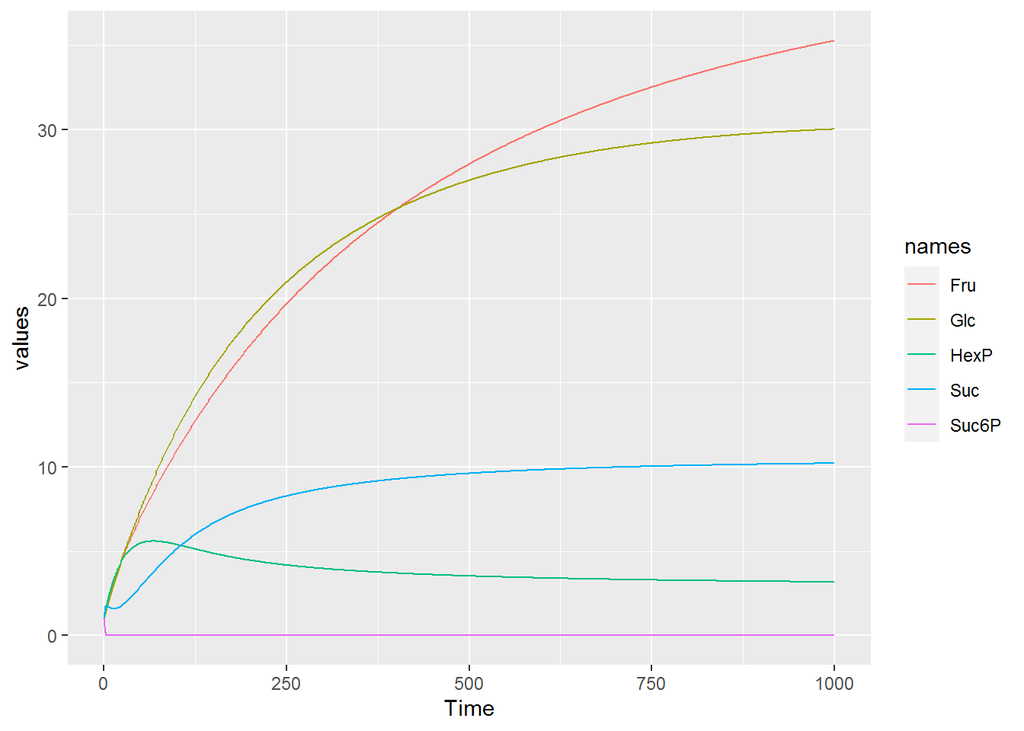

# The objective function

We want to maximize our productivity, which we can define as the ratio of fluxes of accumulation over hydrolysis. $J_{v11}/J_{v9} $. For our optimization algorithms it is necessary to define our optimization goal as a minimum: we want to minimize $J_{v9}/J_{v11}$

What we just defined is called an *objective function*.

In **CoRC** we can define the objective function like this:

```r
objf <- paste0(reaction("(v9)", reference = "Flux"), "/", reaction("(v11)", reference = "Flux"))
getValue(objf)
```

```
## [1] 0.3122084
```

# The parameters

Now we have to think about, what we are able to change to reach the minimum possible value for our objective function. We can assume for this teaching example that we are able to manipulate the steady state levels of our enzymes in reactions *v1*, *v2*, *v3*, *v4* and *v5*.

We have to tell **CoRC** about our optimization parameters like this: We could also specify our parameters more closely, e.g. give them a specific starting value or bounds on how far the estimation is allowed to search. We will say that we can downregulate an enzyme by 50% and overexpress it by 400%. The start values are supposed to be the current values in our model.

```r
make_opt_param <- function(name) {
  value_ref <- parameter_strict(name, reference = "Value")
  value <- getValue(value_ref)
  defineOptimizationParameter(ref = value_ref,
                              start_value = value,
                              lower_bound = 0.5 * value,
                              upper_bound = 4 * value)
}

parameters <- lapply(c("(v1).Vmax1", "(v2).Vmax2", "(v3).Vmax3", "(v4).Vmax4", "(v5).Vmax5"), make_opt_param)
```

# Optimization method

Now we have to choose which optimization method we will use for optimization. For our first try we will use *Truncated Newton*. There are a lot of different methods available in **CoRC** which you can find in the documentation of the runOptimization() function.

```r
method <- 'TruncatedNewton'
```

# Optimization

```r
par_before <- getParameters()$value

result <- runOptimization(expression = objf,
                subtask = 'steadyState',
                randomize_start_values = FALSE,
                update_model = TRUE,
                parameters = parameters,
                method = method)
result$main$objective_value
```

```
## [1] 0.07816841
```

```r
result$parameters
```

```
## # A tibble: 5 x 6
##   parameter  lower_bound start_value  value upper_bound gradient
##   <chr>            <dbl>       <dbl>  <dbl>       <dbl>    <dbl>
## 1 (v1).Vmax1      0.143       0.339  0.339        1.14  -0.254
## 2 (v2).Vmax2      0.143       0.342  0.342        1.14  -0.225
## 3 (v3).Vmax3      0.0985      0.0985 0.0985       0.788  1.21
## 4 (v4).Vmax4      0.0985      0.196  0.196        0.788  0.00801
## 5 (v5).Vmax5      0.082       0.134  0.134        0.656  0.185
```

Our new model with the updated parameter values looks like this:

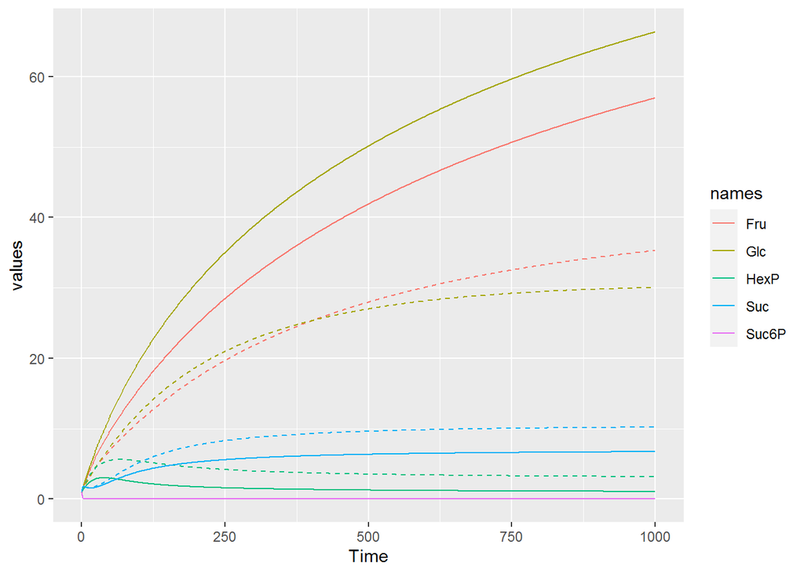

The dashed lines where from the timecourse before the optimization, so we can see that our optimization routine worked!

## References

[^1]: Mendes P., Hoops S., Sahle S., Gauges R., Dada J., Kummer U. (2009) Computational Modeling of Biochemical Networks Using COPASI. In: Maly I. (eds) Systems Biology. Methods in Molecular Biology (Methods and Protocols), vol 500. Humana Press. https://doi.org/10.1007/978-1-59745-525-1_2
[^2]: Rohwer, Johann M., and Frederik C. Botha. “Analysis of sucrose accumulation in the sugar cane culm on the basis of in vitro kinetic data.” Biochemical Journal 358.2 (2001): 437-445.